# SMAGL Notebook - Spring 2021

Nick Mikulski

2/5/2021

# 1 Introduction

This document will serve as my lab notebook for SMAGL research under Prof. Christopher Schmitt during the Spring 2021 semester. My research for credit application was approved on Feb. 5, 2021.

[Application](https://docs.google.com/document/d/1ODJpSP9Owl21iwok2X3M-f-7nAIKtkkMasPKDSp8i4g/edit?usp=sharing)

## 1.1 Goals for the semester

Given that my main academic interests are in conservation biology, I look forward to being able to work with Laura Angley and assist with her research on the release of rehabilitated vervet monkey populations.

- Learn how to conduct a social network analysis in R
- Using the rehabilitated vervet monkey dataset, analyze the social networks of the pre-release and post-release populations
- Compare pre-release and post-release networks to look for patterns such as rank and centrality and to identify possible vulnerabilities in the network

# 2 Learning to use SNA R Packages

## 2.1 Walk through of: McFarland *et al.* 2010

[McFarland DA, Messing S, Nowak M, Westwood SJ. (2010) Network Analysis Labs in R and SoNIA.](https://sna.stanford.edu/rlabs.php)

**Inputting Data from website**  
source(“http://sna.stanford.edu/setup.R”)  
install.packages(“igraph”)  
library(igraph)

```r
advice_data_frame <- read.table('http://sna.stanford.edu/sna_R_labs/data/Krack-High-Tec-edgelist-Advice.txt')
friendship_data_frame <- read.table('http://sna.stanford.edu/sna_R_labs/data/Krack-High-Tec-edgelist-Friendship.txt')
reports_to_data_frame <- read.table('http://sna.stanford.edu/sna_R_labs/data/Krack-High-Tec-edgelist-ReportsTo.txt')

head(advice_data_frame)
```

```
##   V1 V2 V3
## 1  1  1  0
## 2  1  2  1
## 3  1  3  0
## 4  1  4  1
## 5  1  5  0
## 6  1  6  0
```

```r
attributes <- read.csv('http://sna.stanford.edu/sna_R_labs/data/Krack-High-Tec-Attributes.csv', header=T)
attributes
```

```
##    AGE TENURE LEVEL DEPT
## 1   33  9.333     3    4
## 2   42 19.583     2    4
## 3   40 12.750     3    2
## 4   33  7.500     3    4
## 5   32  3.333     3    2
## 6   59 28.000     3    1
## 7   55 30.000     1    0
## 8   34 11.333     3    1
## 9   62  5.417     3    2
## 10  37  9.250     3    3
## 11  46 27.000     3    3
## 12  34  8.917     3    1
## 13  48  0.250     3    2
## 14  43 10.417     2    2
## 15  40  8.417     3    2
## 16  27  4.667     3    4
## 17  30 12.417     3    1
## 18  33  9.083     2    3
## 19  32  4.833     3    2
## 20  38 11.667     3    2
## 21  36 12.500     2    1
```

Adding column names for organization

```r
colnames(advice_data_frame) <- c('ego', 'alter', 'advice_tie')
head(advice_data_frame)
```

```
##   ego alter advice_tie
## 1   1     1          0
## 2   1     2          1
## 3   1     3          0
## 4   1     4          1
## 5   1     5          0
## 6   1     6          0
```

```r
colnames(friendship_data_frame) <- c('ego', 'alter', 'friendship_tie')
head(friendship_data_frame)
```

```
##   ego alter friendship_tie
## 1   1     1              0
## 2   1     2              1
## 3   1     3              0
## 4   1     4              1
## 5   1     5              0
## 6   1     6              0
```

```r
colnames(reports_to_data_frame) <- c('ego', 'alter', 'reports_to_tie')
head(reports_to_data_frame)
```

```
##   ego alter reports_to_tie
## 1   1     1              0
## 2   1     2              1
## 3   1     3              0
## 4   1     4              0
## 5   1     5              0
## 6   1     6              0
```

These lines open the partial data frames in an XQuartz window, but I took out of chunk because it was messing up the knitting of the file.

fix(advice_data_frame)  
fix(friendship_data_frame)  
fix(reports_to_data_frame)

Confirms that our columns and rows align before combining the data set:

```r
advice_data_frame$ego == friendship_data_frame$ego
```

```
##   [1] TRUE TRUE TRUE TRUE TRUE TRUE TRUE TRUE TRUE TRUE TRUE TRUE TRUE TRUE TRUE
##  [16] TRUE TRUE TRUE TRUE TRUE TRUE TRUE TRUE TRUE TRUE TRUE TRUE TRUE TRUE TRUE
##  [31] TRUE TRUE TRUE TRUE TRUE TRUE TRUE TRUE TRUE TRUE TRUE TRUE TRUE TRUE TRUE
##  [46] TRUE TRUE TRUE TRUE TRUE TRUE TRUE TRUE TRUE TRUE TRUE TRUE TRUE TRUE TRUE
##  [61] TRUE TRUE TRUE TRUE TRUE TRUE TRUE TRUE TRUE TRUE TRUE TRUE TRUE TRUE TRUE
##  [76] TRUE TRUE TRUE TRUE TRUE TRUE TRUE TRUE TRUE TRUE TRUE TRUE TRUE TRUE TRUE
##  [91] TRUE TRUE TRUE TRUE TRUE TRUE TRUE TRUE TRUE TRUE TRUE TRUE TRUE TRUE TRUE
## [106] TRUE TRUE TRUE TRUE TRUE TRUE TRUE TRUE TRUE TRUE TRUE TRUE TRUE TRUE TRUE
## [121] TRUE TRUE TRUE TRUE TRUE TRUE TRUE TRUE TRUE TRUE TRUE TRUE TRUE TRUE TRUE
## [136] TRUE TRUE TRUE TRUE TRUE TRUE TRUE TRUE TRUE TRUE TRUE TRUE TRUE TRUE TRUE
## [151] TRUE TRUE TRUE TRUE TRUE TRUE TRUE TRUE TRUE TRUE TRUE TRUE TRUE TRUE TRUE
## [166] TRUE TRUE TRUE TRUE TRUE TRUE TRUE TRUE TRUE TRUE TRUE TRUE TRUE TRUE TRUE
## [181] TRUE TRUE TRUE TRUE TRUE TRUE TRUE TRUE TRUE TRUE TRUE TRUE TRUE TRUE TRUE
## [196] TRUE TRUE TRUE TRUE TRUE TRUE TRUE TRUE TRUE TRUE TRUE TRUE TRUE TRUE TRUE
## [211] TRUE TRUE TRUE TRUE TRUE TRUE TRUE TRUE TRUE TRUE TRUE TRUE TRUE TRUE TRUE
## [226] TRUE TRUE TRUE TRUE TRUE TRUE TRUE TRUE TRUE TRUE TRUE TRUE TRUE TRUE TRUE
## [241] TRUE TRUE TRUE TRUE TRUE TRUE TRUE TRUE TRUE TRUE TRUE TRUE TRUE TRUE TRUE
## [256] TRUE TRUE TRUE TRUE TRUE TRUE TRUE TRUE TRUE TRUE TRUE TRUE TRUE TRUE TRUE
## [271] TRUE TRUE TRUE TRUE TRUE TRUE TRUE TRUE TRUE TRUE TRUE TRUE TRUE TRUE TRUE
## [286] TRUE TRUE TRUE TRUE TRUE TRUE TRUE TRUE TRUE TRUE TRUE TRUE TRUE TRUE TRUE
## [301] TRUE TRUE TRUE TRUE TRUE TRUE TRUE TRUE TRUE TRUE TRUE TRUE TRUE TRUE TRUE
## [316] TRUE TRUE TRUE TRUE TRUE TRUE TRUE TRUE TRUE TRUE TRUE TRUE TRUE TRUE TRUE
## [331] TRUE TRUE TRUE TRUE TRUE TRUE TRUE TRUE TRUE TRUE TRUE TRUE TRUE TRUE TRUE
## [346] TRUE TRUE TRUE TRUE TRUE TRUE TRUE TRUE TRUE TRUE TRUE TRUE TRUE TRUE TRUE
## [361] TRUE TRUE TRUE TRUE TRUE TRUE TRUE TRUE TRUE TRUE TRUE TRUE TRUE TRUE TRUE
## [376] TRUE TRUE TRUE TRUE TRUE TRUE TRUE TRUE TRUE TRUE TRUE TRUE TRUE TRUE TRUE
## [391] TRUE TRUE TRUE TRUE TRUE TRUE TRUE TRUE TRUE TRUE TRUE TRUE TRUE TRUE TRUE
## [406] TRUE TRUE TRUE TRUE TRUE TRUE TRUE TRUE TRUE TRUE TRUE TRUE TRUE TRUE TRUE
## [421] TRUE TRUE TRUE TRUE TRUE TRUE TRUE TRUE TRUE TRUE TRUE TRUE TRUE TRUE TRUE
## [436] TRUE TRUE TRUE TRUE TRUE TRUE
```

```r
which(advice_data_frame$ego != friendship_data_frame$ego)
```

```
## integer(0)
```

```r
which(advice_data_frame$alter != friendship_data_frame$alter)
```

```
## integer(0)
```

```r
which(reports_to_data_frame$alter != friendship_data_frame$alter)
```

```
## integer(0)
```

```r
which(reports_to_data_frame$ego != friendship_data_frame$ego)
```

```
## integer(0)
```

Combining them into one data frame:

```r
krack_full_data_frame <- cbind(advice_data_frame,
    friendship_data_frame$friendship_tie,
    reports_to_data_frame$reports_to_tie)
head(krack_full_data_frame)
```

```
##   ego alter advice_tie friendship_data_frame$friendship_tie
## 1   1     1          0                                    0
## 2   1     2          1                                    1
## 3   1     3          0                                    0
## 4   1     4          1                                    1
## 5   1     5          0                                    0
## 6   1     6          0                                    0
##   reports_to_data_frame$reports_to_tie
## 1                                    0
## 2                                    1
## 3                                    0
## 4                                    0
## 5                                    0
## 6                                    0
```

Rename columns to organize better:

```r
names(krack_full_data_frame)[4:5] <- c("friendship_tie",
    "reports_to_tie")
head(krack_full_data_frame)
```

```
##   ego alter advice_tie friendship_tie reports_to_tie
## 1   1     1          0              0              0
## 2   1     2          1              1              1
## 3   1     3          0              0              0
## 4   1     4          1              1              0
## 5   1     5          0              0              0
## 6   1     6          0              0              0
```

```r
krack_full_nonzero_edges <- subset(krack_full_data_frame,
    (advice_tie > 0 | friendship_tie > 0 | reports_to_tie > 0))
head(krack_full_nonzero_edges)
```

```
##    ego alter advice_tie friendship_tie reports_to_tie
## 2    1     2          1              1              1
## 4    1     4          1              1              0
## 8    1     8          1              1              0
## 12   1    12          0              1              0
## 16   1    16          1              1              0
## 18   1    18          1              0              0
```

Reduce to only non-zero edges to only contain actual connections:

```r
library(igraph) #Unsure why, but it fails every time if not reloaded within the chunk
krack_full <- graph.data.frame(krack_full_nonzero_edges)
summary(krack_full)
```

```
## IGRAPH 49e87ff DN-- 21 232 --
## + attr: name (v/c), advice_tie (e/n), friendship_tie (e/n),
## | reports_to_tie (e/n)
```

```r
krack_full
```

```
## IGRAPH 49e87ff DN-- 21 232 --
## + attr: name (v/c), advice_tie (e/n), friendship_tie (e/n),
## | reports_to_tie (e/n)
## + edges from 49e87ff (vertex names):
##  [1] 1->2  1->4  1->8  1->12 1->16 1->18 1->21 2->1  2->6  2->7  2->18 2->21
## [13] 3->1  3->2  3->4  3->6  3->7  3->8  3->9  3->10 3->11 3->12 3->14 3->17
## [25] 3->18 3->19 3->20 3->21 4->1  4->2  4->6  4->8  4->10 4->11 4->12 4->16
## [37] 4->17 4->18 4->20 4->21 5->1  5->2  5->6  5->7  5->8  5->9  5->10 5->11
## [49] 5->13 5->14 5->16 5->17 5->18 5->19 5->20 5->21 6->2  6->7  6->9  6->12
## [61] 6->17 6->21 7->2  7->6  7->11 7->12 7->14 7->17 7->18 7->21 8->2  8->4
## [73] 8->6  8->7  8->10 8->11 8->18 8->21 9->1  9->2  9->6  9->7  9->8  9->10
## + ... omitted several edges
```

Create vectors of specific edge types:

```r
get.edge.attribute(krack_full, 'advice_tie')
```

```
##   [1] 1 1 1 0 1 1 1 0 1 1 0 1 1 1 1 1 1 1 1 1 1 1 1 1 1 0 1 1 1 1 1 1 1 1 1 1 1
##  [38] 1 1 1 1 1 1 1 1 0 1 1 1 1 1 1 1 1 1 1 0 0 0 0 0 1 1 1 1 1 1 1 1 1 1 1 1 1
##  [75] 1 1 1 1 1 1 1 1 1 1 1 1 1 1 1 1 1 1 1 1 1 1 1 0 1 0 1 1 1 1 1 1 1 1 1 0 0
## [112] 0 1 0 0 0 0 0 0 0 0 0 0 1 0 1 1 1 1 1 0 1 1 1 1 0 1 1 1 1 1 1 1 1 1 1 1 1
## [149] 1 1 1 1 1 1 1 1 1 1 1 1 1 1 1 1 0 1 0 0 1 0 0 0 0 0 0 0 0 0 0 1 1 1 1 1 1
## [186] 1 1 1 1 1 1 1 1 1 1 1 1 1 1 1 1 1 1 1 0 1 1 1 1 1 1 1 1 1 1 1 1 1 1 1 1 1
## [223] 1 1 1 1 1 1 1 1 1 1
```

```r
get.edge.attribute(krack_full, 'friendship_tie')
```

```
##   [1] 1 1 1 1 1 0 0 1 0 0 1 1 0 0 0 0 0 0 0 0 0 0 1 0 0 1 0 0 1 1 0 1 0 0 1 1 1
##  [38] 0 0 0 0 1 0 0 0 1 0 1 0 1 0 1 0 1 0 1 1 1 1 1 1 1 0 0 0 0 0 0 0 0 0 1 0 0
##  [75] 0 0 0 0 0 0 0 0 0 0 0 0 0 0 0 0 0 0 0 1 0 1 1 1 0 1 0 0 1 0 0 0 1 1 1 1 1
## [112] 1 0 1 1 1 1 1 1 1 1 1 1 0 1 1 0 0 1 0 1 0 0 0 1 1 0 0 1 0 1 0 1 1 0 0 1 0
## [149] 1 0 0 1 0 0 0 1 0 0 1 1 0 0 1 1 1 1 1 1 1 1 1 1 1 1 1 1 1 1 1 1 0 1 0 0 0
## [186] 0 0 0 0 0 0 0 0 0 0 0 0 1 1 1 1 0 0 1 1 1 1 0 1 0 0 0 0 1 0 0 0 0 0 1 0 1
## [223] 0 0 0 0 0 1 0 1 1 0
```

```r
get.edge.attribute(krack_full, 'reports_to_tie')
```

```
##   [1] 1 0 0 0 0 0 0 0 0 1 0 0 0 0 0 0 0 0 0 0 0 0 1 0 0 0 0 0 0 1 0 0 0 0 0 0 0
##  [38] 0 0 0 0 0 0 0 0 0 0 0 0 1 0 0 0 0 0 0 0 0 0 0 0 1 0 0 0 0 0 0 0 0 0 0 0 0
##  [75] 0 0 0 1 0 0 0 0 0 0 0 0 1 0 0 0 0 0 0 0 0 0 0 0 0 0 0 0 0 0 1 0 0 0 0 0 0
## [112] 0 0 0 0 0 0 0 0 1 0 0 0 0 0 1 0 0 0 0 0 1 0 0 1 0 0 0 0 0 0 0 0 0 0 0 0 0
## [149] 0 0 0 1 0 0 0 0 0 0 0 1 0 0 0 0 0 0 0 0 0 0 0 0 0 0 0 0 0 0 0 1 0 0 0 0 0
## [186] 1 0 0 0 0 0 0 0 0 0 0 0 0 0 0 0 0 0 0 0 1 0 0 0 0 0 0 0 0 0 1 0 0 0 0 0 0
## [223] 0 0 0 1 0 0 0 0 0 0
```

Symmetrize the network, making all asymmetric ties symmetric:

```r
krack_full_symmetrized <- as.undirected(krack_full, mode='collapse')
summary(krack_full_symmetrized)
```

```
## IGRAPH a5d040d UN-- 21 159 --
## + attr: name (v/c)
```

**Adding Attributes to the Graph**  
Create a vector of vertex labels

```r
attributes = cbind(1:length(attributes[,1]), attributes) #I'm a little confused on the arguments within esp the [,1]
krack_full <- graph.data.frame(d = krack_full_nonzero_edges,
                               vertices = attributes)


#Attributes (age, tensure, level, and dept) are now listed alongside name as vertex attributes
summary(krack_full)
```

```
## IGRAPH e9f1343 DN-- 21 232 --
## + attr: name (v/c), AGE (v/n), TENURE (v/n), LEVEL (v/n), DEPT (v/n),
## | advice_tie (e/n), friendship_tie (e/n), reports_to_tie (e/n)
```

?cbind

List all values for a given attribute

```r
get.vertex.attribute(krack_full, 'AGE')
```

```
##  [1] 33 42 40 33 32 59 55 34 62 37 46 34 48 43 40 27 30 33 32 38 36
```

```r
get.vertex.attribute(krack_full, 'TENURE')
```

```
##  [1]  9.333 19.583 12.750  7.500  3.333 28.000 30.000 11.333  5.417  9.250
## [11] 27.000  8.917  0.250 10.417  8.417  4.667 12.417  9.083  4.833 11.667
## [21] 12.500
```

```r
get.vertex.attribute(krack_full, 'LEVEL')
```

```
##  [1] 3 2 3 3 3 3 1 3 3 3 3 3 3 2 3 3 3 2 3 3 2
```

```r
get.vertex.attribute(krack_full, 'DEPT')
```

```
##  [1] 4 4 2 4 2 1 0 1 2 3 3 1 2 2 2 4 1 3 2 2 1
```

**Visualizing the network**  
Plot of initial network

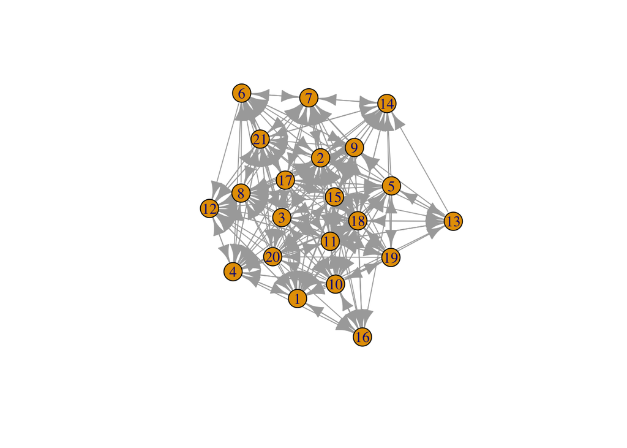

```r
plot(krack_full)
```

Saves plotted graph as a pdf:

```r
setwd("/users/nickmikulski/Desktop/SMAGL/Spring2021") #set working directory to define where pdf will be save to
pdf("1.1_Krackhardt_Full.pdf")
plot(krack_full)
dev.off() #this line ends the pdf save process?
```

?delete.edges (graph, edges-to-be-deleted)

?E

?get.edge.attribute

This network is very messy and unclear, so the lines below reduce to just one edge type in the network.

```r
#First, just the advice edges
krack_advice_only <- delete.edges(krack_full, #delete edges within krack_full:
    E(krack_full)[get.edge.attribute(krack_full, #E(krack_full) gives all edges; [get. argument keeps just the advice edges
    name = "advice_tie") == 0])
summary(krack_advice_only)
```

```
## IGRAPH 39fe066 DN-- 21 190 --
## + attr: name (v/c), AGE (v/n), TENURE (v/n), LEVEL (v/n), DEPT (v/n),
## | advice_tie (e/n), friendship_tie (e/n), reports_to_tie (e/n)
```

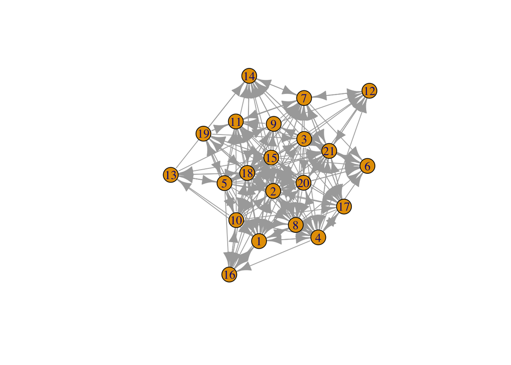

```r
plot(krack_advice_only) #still very messy
```

```r
#Friendship edges only
krack_friendship_only <- delete.edges(krack_full,
    E(krack_full)[get.edge.attribute(krack_full,
    name = "friendship_tie") == 0])
summary(krack_friendship_only)
```

```
## IGRAPH 90c93b7 DN-- 21 102 --
## + attr: name (v/c), AGE (v/n), TENURE (v/n), LEVEL (v/n), DEPT (v/n),
## | advice_tie (e/n), friendship_tie (e/n), reports_to_tie (e/n)
```

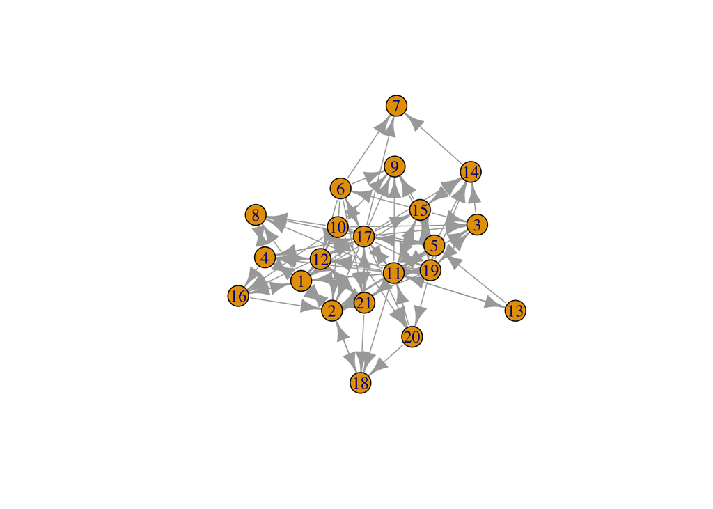

```r
plot(krack_friendship_only)
```

```r
#Reports to edges only
krack_reports_to_only <- delete.edges(krack_full,
    E(krack_full)[get.edge.attribute(krack_full,
    name = "reports_to_tie") == 0])
summary(krack_reports_to_only)
```

```
## IGRAPH 7401dc8 DN-- 21 20 --
## + attr: name (v/c), AGE (v/n), TENURE (v/n), LEVEL (v/n), DEPT (v/n),
## | advice_tie (e/n), friendship_tie (e/n), reports_to_tie (e/n)
```

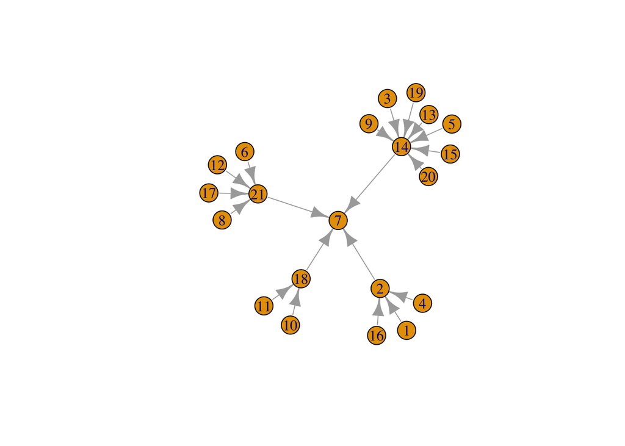

```r
plot(krack_reports_to_only) #This is very interesting. It is definitely the most orderly network, which makes sense for "reports to."
```

I hope to be able to create a network similar to this with our real data to be able to see which individual vervets are central to the group.